# Power of Random Forests in Business

Analysis & Results

Author

Stutti (Advisor: Dr. Seals)

Published

November 11, 2024

# Analysis and Results

## SSI Sales Dataset

The source data contained sales transactions for a span of 48 months and came from SSI, a Florida based B2B2C type company. The company offers custom packaging in the food industry. It offers custom branding and design as well as actual supply of the products. Customers may have transactional based sales where each order serves as it’s own agreement or customers may have a long term contract where they agree to purchase a product or several products through the course of a six month period or a year, or agree to purchase a set quantity over a period of time, for example. Once these agreements are established, the customer instructs it’s distributor to purchase from SSI and deliver to them. So, the purchase order, in reality comes from this distributor and not the end client. The data extracted contains information on both the distributor as well as the end client. It also contains product information as well as delivery location. The SQL code used to extract this data is included in the Appendix.

Below you will find the data dictionary of the SSI Sales data.

| Data Dictionary |  |  |
| --- | --- | --- |
| Attribute | Format | Description |
| OPCO | Varchar | The customer placing the order. In this case, typically a Distributor. |
| SalesOrderID | Varchar | Unique identifier assigned to each sales order. |
| CustomerPO | Varchar | Customer’s identifier of their order sent to BCC. |
| Product | Varchar | Unique identifier assigned to each product. |
| Description | Varchar | Description of the product being sold. |
| Substrate | Varchar | Type of product/material. |
| RequestedDeliveryDate | Varchar | Date the delivery was scheduled originally. |
| DateFulfilled | Varchar | Date the delivery was made. |
| qtyOrdered | Numeric | Quantity ordered on the order. |
| qtyFulfilled | Numeric | Quantity delivered on the order. |
| UnitPrice | Numeric | Price of each case of product SSI charges the customer. |
| TotalPrice | Numeric | Total price of the sales order. |
| Class | Varchar | Customer name |
| ShipToName | Varchar | Address name of ordering party |
| ShipToAddress | Varchar | Address where order needs to be delivered |
| SalesOrderStatus | Varchar | Status of Sales order |
| SalesItemStatus | Varchar | Status of each line item on the sales order |

## Load Data

The data available in a CSV file was read into and loaded in RStudio. Below is a snapshot of the file. The base file had 33,818 observations and 17 variables in the data.

```r
library(tidyverse)
library(knitr)
SaleData <- read_csv('/Users/ss/Documents/HR Misc/Masters/IDC6940 Capstone in Data Science/Data/DataSet1.csv')

kable(head(SaleData))
```

| OPCO | SalesOrderID | CustomerPO | Product | Description | Substrate | RequestedDeliveryDate | DateFulfilled | qtyOrdered | QuantityFulfilled | UnitPrice | TotalPrice | Class | ShipToName | ShipToAddress | SalesOrderStatus | SalesItemStatus |
| --- | --- | --- | --- | --- | --- | --- | --- | --- | --- | --- | --- | --- | --- | --- | --- | --- |
| .Berl Company - Orlando - Millenia | 9969-2 | NA | WS-INDSC-02 | Wings .75” Label Sweet DineLink 500/rl | paper | 10/13/22 | 10/13/2022 | 122 | 122 | 2.5 | 305 | Click & Chew | .Berl Company - Orlando | Michael B 4700 Millenia BLVD Suite 405, Orlando, FL | Fulfilled | Fulfilled |
| .Berl Company - Orlando - Millenia | 9969-2 | NA | WS-INDHG-02 | Wings .75” Label Honey Garlic 500/rl | paper | 10/13/22 | 10/13/2022 | 66 | 66 | 2.5 | 165 | Click & Chew | .Berl Company - Orlando | Michael B 4700 Millenia BLVD Suite 405, Orlando, FL | Fulfilled | Fulfilled |
| .Berl Company - Orlando - Millenia | 9969-2 | NA | NA | Subtotal | NA | 10/13/22 | 10/13/2022 | 1 | 1 | 0 | 1105 | Click & Chew | .Berl Company - Orlando | Michael B 4700 Millenia BLVD Suite 405, Orlando, FL | Fulfilled | Fulfilled |
| .Bird Boss - Disney Springs | 8341 | NA | CG-SW-02 4M | Bird Boss Sandwich Wrap 13x13 | paper | 4/13/22 | 4/19/2022 | 3 | 3 | 84 | 252 | Berl Company | .Bird Boss - Disney Springs | 1506 East Buena Vista Dr, Orlando, FL | Fulfilled | Fulfilled |
| .Bird Boss - Disney Springs | 8341 | NA | Shipping Charge | Shipping Charge | other | 4/13/22 | 4/19/2022 | 1 | 1 | 43.69 | 43.69 | Berl Company | .Bird Boss - Disney Springs | 1506 East Buena Vista Dr, Orlando, FL | Fulfilled | Fulfilled |
| .Bird Boss - Lake Buena Vista | 10691 | NA | CG-CBX-01 | Bird Boss Catering Box 2 Sauce Holders each side 40/bundle | cardboard | 2/1/23 | 1/31/2023 | 2 | 2 | 79.6 | 159.2 | Bird Boss | .Bird Boss - Lake Buena Vista | 1506 E. Buena Drive Suite A, Lake Buena Vista, FL | Fulfilled | Fulfilled |

Below you will find visualizations of some of the key data features used in this research paper. The distributions helped uncover negative values, outliers and aided with data processing.

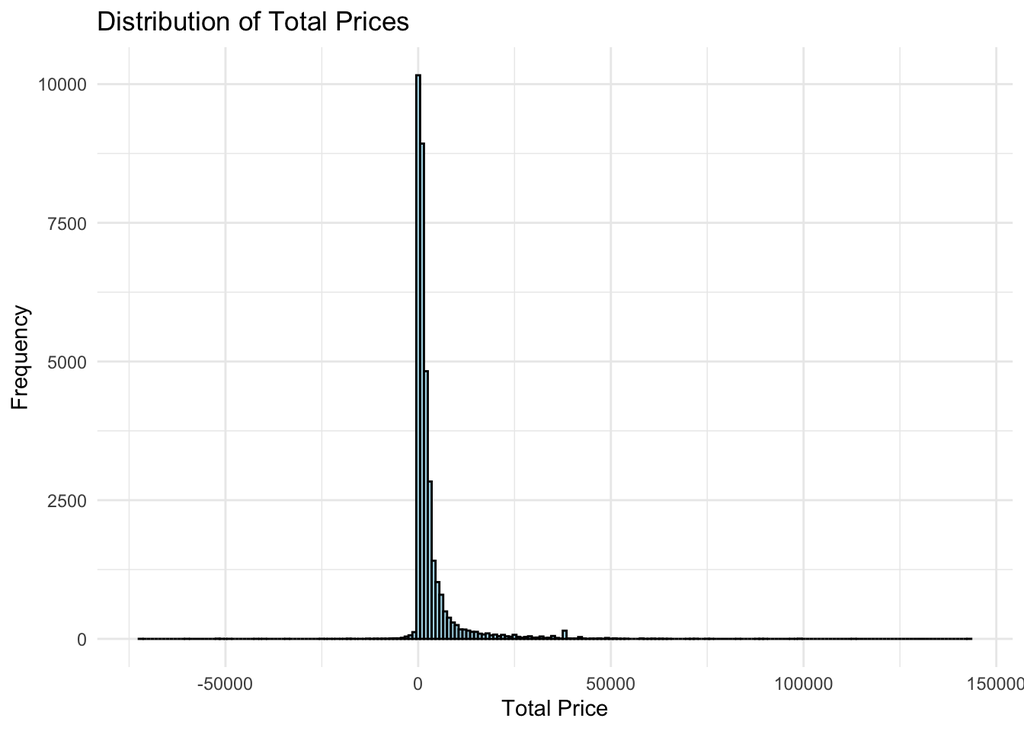

```r
library(tidyverse)
library(ggplot2)
SaleData <- read_csv('/Users/ss/Documents/HR Misc/Masters/IDC6940 Capstone in Data Science/Data/DataSet1.csv')

# 1: Create a histogram of totalprice across sales orders
ggplot(SaleData, aes(x = TotalPrice)) +
  geom_histogram(binwidth = 1000, fill = "lightblue", color = "black") +
  theme_minimal() +
  labs(title = "Distribution of Total Prices", x = "Total Price", y = "Frequency")
```

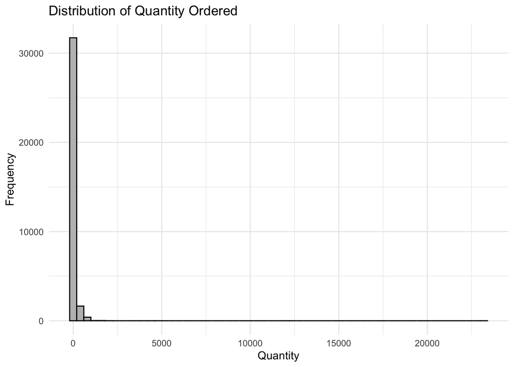

```r
#summary(SaleData$TotalPrice)

# 2: Create a histogram of quantity across sales orders
ggplot(SaleData, aes(x = qtyOrdered)) +
  geom_histogram(binwidth = 400, fill = "gray", color = "black") +
  theme_minimal() +
  labs(title = "Distribution of Quantity Ordered", x = "Quantity", y = "Frequency")
```

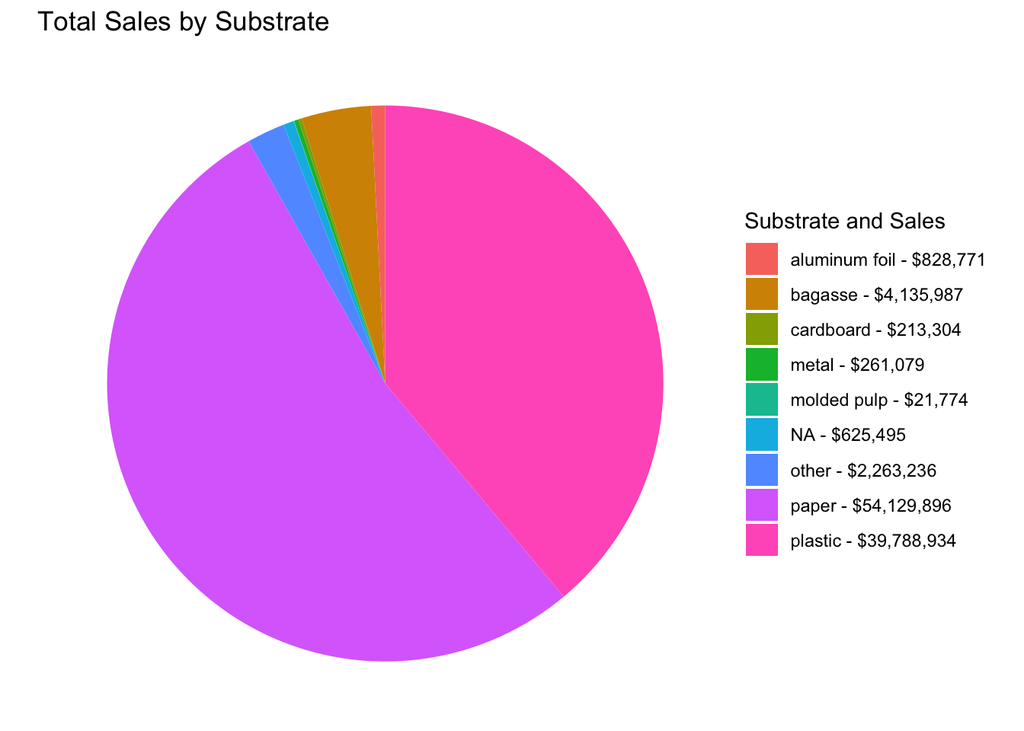

```r
#summary(SaleData$qtyOrdered)

library(scales)
# 3: Create a pie chart for TotalSales by Substrate
substrate_sales <- SaleData %>%
  group_by(Substrate) %>%
  summarise(TotalSubstrateSales = sum(TotalPrice, na.rm = TRUE)) %>%
  arrange(desc(TotalSubstrateSales))

# configure sales to currency
substrate_sales$legend_label <- paste(substrate_sales$Substrate, "-", dollar(substrate_sales$TotalSubstrateSales))

ggplot(substrate_sales, aes(x = "", y = TotalSubstrateSales, fill = legend_label)) +
  geom_bar(stat = "identity", width = 1) +  # Create bar chart
  coord_polar("y") +  # Convert bar chart to pie chart
  labs(title = "Total Sales by Substrate", fill = "Substrate and Sales") +
  theme_void()  # Remove axis labels and background
```

The visualizations were helpful in realizing what data processing was needed and what our target data should be. Below are the findings:

## Preprocessing of Data

The dataset consisted of sales returns and credits to the customer. These were excluded in order to avoid false outcomes and predictions. There were also records related to shipping costs that were excluded. As an example, there may have been out of the norm activity when SSI encountered inbound shipment delays and SSI needed to airfreight product to customers at a higher than normal shipping rate. We do not want skewed results and hence, this activity was omitted.

Below are some visualizations that show performance by Product, Price and Total Sales for SSI.

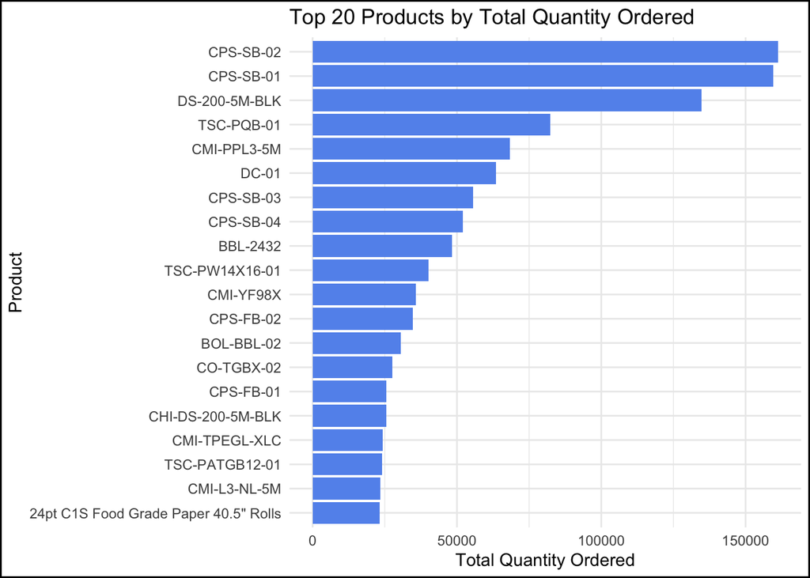

```r
# Load necessary libraries
library(tidyverse)
library(dplyr)
library(ggplot2)
library(knitr)

#Load data
SaleData <- read_csv('/Users/ss/Documents/HR Misc/Masters/IDC6940 Capstone in Data Science/Data/DataSet1.csv')

# List of products to exclude
exclude_products <- c("OUTBOUND SHIPPING", "Outbound Shipping", "Shipping Charge", "SHIPPING CHARGE")

# Filter out returns/credits (Price <= 0) and shipping charges
SaleData1 <- SaleData %>%
  filter(UnitPrice > 0, TotalPrice > 0, !Product %in% exclude_products)

# 1: Bar chart: Top 20 Products by Qty Ordered
product_qty <- SaleData1 %>%
  group_by(Product) %>%
  summarise(TotalQuantityOrdered = sum(qtyOrdered, na.rm = TRUE)) %>%
  arrange(desc(TotalQuantityOrdered)) %>%
  head(20)

ggplot(product_qty, aes(x = reorder(Product, TotalQuantityOrdered), y = TotalQuantityOrdered)) +
  geom_bar(stat = "identity", fill = "cornflowerblue") +
  theme_minimal() +
  coord_flip() +
  labs(title = "Top 20 Products by Total Quantity Ordered", x = "Product", y = "Total Quantity Ordered")+
  theme(
    plot.background = element_rect(color = "black", fill = NA, size = 1)  # Adds a black border around the plot area
  )
```

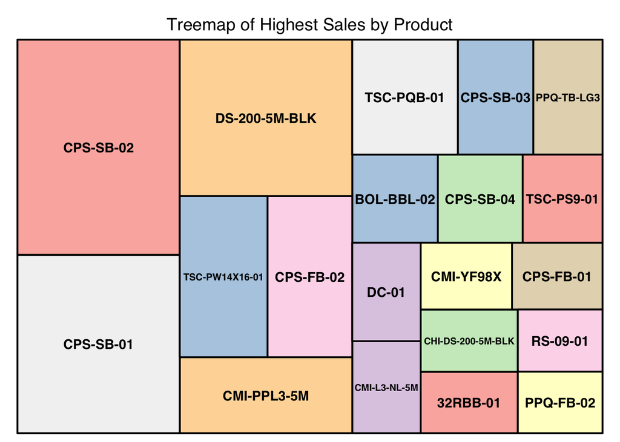

```r
# Create a treemap of total sales by product
library(treemap)

product_sales <- SaleData1 %>%
  filter(!Product %in% exclude_products) %>%
  group_by(Product) %>%
  summarise(pSales = sum(TotalPrice, na.rm = TRUE)) %>%
  arrange(desc(pSales)) %>%
  head(20)

# Create a treemap of total sales by product
treemap(product_sales,
        index = "Product",
        vSize = "pSales",
        title = "Treemap of Highest Sales by Product",
        palette = "Pastel1") # "PuBu"
```

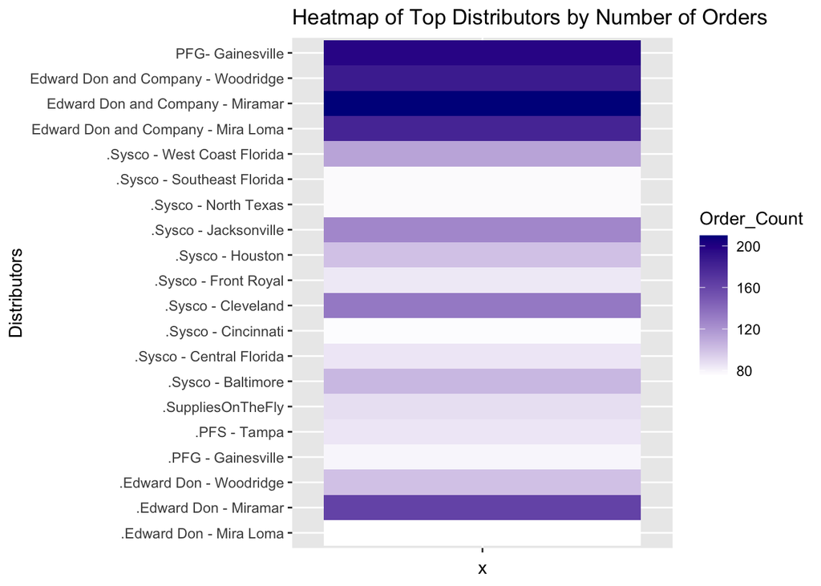

```r
# Create heatmap - Top distributors by Orders
top_dist <- SaleData1 %>%
  group_by(OPCO) %>%
  summarise(Order_Count = n_distinct(SalesOrderID)) %>%
  arrange(desc(Order_Count)) %>%
  head(20)

ggplot(top_dist, aes(x = "", y = OPCO, fill = Order_Count)) +
  geom_tile() +
  scale_fill_gradient(low = "white", high = "darkblue") +
  labs(title = "Heatmap of Top Distributors by Number of Orders", y = "Distributors") +
  theme(axis.text.x = element_text(angle = 90, hjust = 1))
```

And lastly, SSI’s sales shown over time in the line plot below.

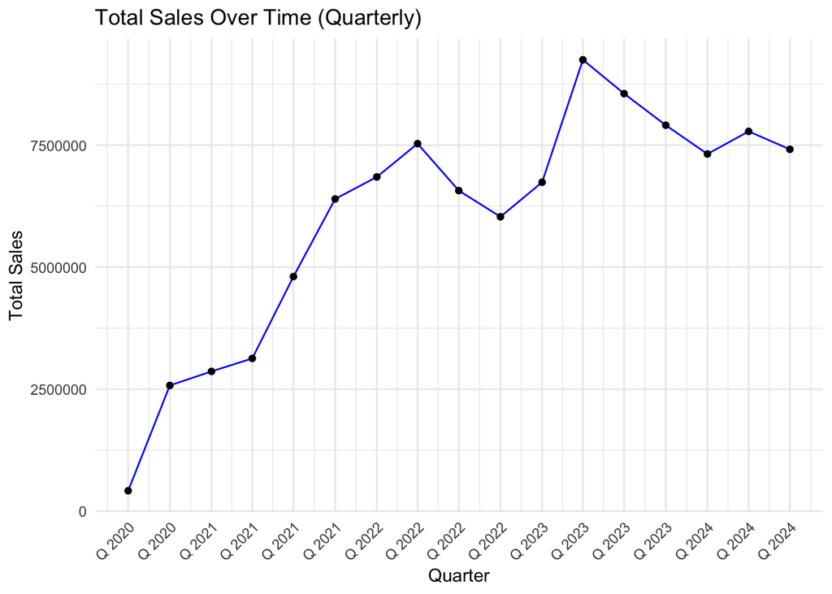

```r
# Sales Over Time
library(lubridate)
library(scales)

# Convert DateFulfilled in date format
### SaleData1$DateFulfilled <- ymd(SaleData1$DateFulfilled) ### Did not work
SaleData1$parsed_dates <- parse_date_time(SaleData1$DateFulfilled, orders = c("ymd", "mdy", "dmy", "Ymd", "Y-m-d"))
SaleData1$parsed_dates <- ymd(SaleData1$parsed_dates)

# Summarize total sales by quarter
sales_over_time <- SaleData1 %>%
  mutate(nDate = floor_date(parsed_dates, "quarter")) %>%
  group_by(nDate) %>%
  summarize(TotalSales = sum(TotalPrice, na.rm = TRUE))

# Create a new variable for quarters
sales_over_time$Quarter <- quarter(sales_over_time$nDate)

# Plot total sales over time with quarterly labels
ggplot(sales_over_time, aes(x = nDate, y = TotalSales)) +
  geom_line(color = "blue") +
  geom_point() +
  scale_x_date(date_labels = "Q% %Y", date_breaks = "3 months") +
  labs(title = "Total Sales Over Time (Quarterly)", x = "Quarter", y = "Total Sales") +
  theme_minimal() +
  theme(axis.text.x = element_text(angle = 45, hjust = 1))
```

Below you will find **Table 1** with some statistics summaries of the data.

|  | Total Orders (n=7585) | Closed Short (n=733) | Fulfilled (n=6852) |
| --- | --- | --- | --- |
| Top Customers |  |  |  |
| Smoothie Island | 1701 (22.43%) | 455 (62.07%) | 1246 (18.18%) |
| Philly Bite | 1556 (20.51%) | 267 (36.43%) | 1289 (18.81%) |
| PlatePioneers | 1396 (18.40%) | 143 (19.51%) | 1253 (18.29%) |
| Berl Company | 906 (11.94%) | 5 (0.68%) | 901 (13.15%) |
| DineLink Intl | 589 (7.77%) | 42 (5.73%) | 547 (7.98%) |
| Top Products |  |  |  |
| DC-01 | 1135 (14.96%) | 345 (47.07%) | 790 (11.53%) |
| TSC-PQB-01 | 1087 (14.33%) | 389 (53.07%) | 698 (10.19%) |
| TSC-PW14X16-01 | 848 (11.18%) | 283 (38.61%) | 565 (8.25%) |
| CMI-PCK-01 | 802 (10.57%) | 288 (39.29%) | 514 (7.50%) |
| PC-05-B1 | 745 (9.82%) | 220 (30.01%) | 525 (7.66%) |
| Top Distributors |  |  |  |
| Ed Don & Company - Miramar | 210 (2.77%) | 0 (0.00%) | 210 (3.06%) |
| PFG- Gainesville | 197 (2.60%) | 0 (0.00%) | 197 (2.88%) |
| Ed Don & Company - Woodridge | 186 (2.45%) | 0 (0.00%) | 186 (2.71%) |
| Ed Don & Company - Mira Loma | 180 (2.37%) | 0 (0.00%) | 180 (2.63%) |
| .Ed Don - Miramar | 162 (2.14%) | 0 (0.00%) | 162 (2.36%) |
| Top Substrates | Paper | Plastic | Bagasse |
| Revenue($103,826,286) | $54,838,585 (52.82%) | $40,336,669 (38.85%) | $4,350,337 (4.19%) |
| Quantity Ordered | Min | Mean | Max |
| Total Ordered(1,971,237) | 1 | 61.47 | 23,160 |
| Unit Price | Min | Mean | Max |
| Key Stats | $0.16 | $62.60 | $864.00 |
| Total Price | Min | Mean | Max |
| Key Stats | $4.92 | $3,430.74 | $143,084.74 |

#### Table 2 - Factors Impacting Consumer Behavior

| Table 2: | Identified Factors having causal impact on consumer buying behavior |  |  |  |  |
| --- | --- | --- | --- | --- | --- |
|  |  | Demographics | Behavioral | Seasonal |  |
|  | Factors | Geography | Product | Quantity |  |
|  |  |  |  |  | Total Price |
|  |  |  |  | Substrate |  |
|  |  |  | Date |  |  |

### Analysis and Results

```r
# Split the data into training and testing sets
set.seed(6079)
trainIndex <- createDataPartition(SaleData1$TotalPrice, p = 0.8, list = FALSE, times = 1)
trainData <- SaleData1[trainIndex, ]
testData  <- SaleData1[-trainIndex, ]

# *Model 1* - Fit a Random Forest model to predict TotalPrice (regression)
rf_model1 <- randomForest(TotalPrice ~ OPCO + Product + Substrate + RequestedDeliveryDate + qtyOrdered +
                            UnitPrice + Class,
                            data = trainData,
                            ntree = 100,  # Number of trees (default is 500)
                            mtry = 3,
                            importance = TRUE,
                            proximity = TRUE,
                            na.action = na.exclude) # call to handle missing values
```

```r
# *Model 2* - Fit a Random Forest model to predict TotalPrice (regression)
rf_model2 <- randomForest(TotalPrice ~ OPCO + Product + Substrate + RequestedDeliveryDate + qtyOrdered +
                          UnitPrice + Class,
                          data = trainData,
                          ntree = 300,  # Number of trees (default is 500)
                          mtry = 3,
                          importance = TRUE,
                          proximity = TRUE,
                          na.action = na.exclude) # call to handle missing values
```

#### Table 3 - Feature Importance

| Table3: | Feature Importance impacting TotalPrice |  |  |
| --- | --- | --- | --- |
|  | Percent Increace in Mean Squared Error |  | Increase in Node Purity |
| qtyOrdered | 115.57 | qtyOrdered | 816,625,361,100 |
| UnitPrice | 67.47 | UnitPrice | 108,382,696,050 |
| Product | 18.24 | Product | 48,552,700,247 |
| Substrate | 13.31 | Class | 43,912,472,740 |
| RequestedDeliveryDate | 11.35 | OPCO | 31,973,554,486 |
| OPCO | 10.72 | RequestedDeliveryDate | 11,687,570,783 |
| Class | 10.42 | Substrate | 7,523,464,034 |

```r
# Get importance of each feature
importance(rf_model1)
importance(rf_model2)

# Get OOB error estimate
print(rf_model1)
print(rf_model2)

# Proximity Matrix
proximity_matrix <- rf_model1$proximity
proximity_matrix2 <- rf_model2$proximity

# Predict TotalPrice on new data
predictions1 <- predict(rf_model1, newdata = testData)
predictions2 <- predict(rf_model2, newdata = testData)

# Calculate residuals - model 1
residuals1 <- testData$TotalPrice - predictions1  # print(residuals1)

# Calculate residuals - model 1
residuals2 <- testData$TotalPrice - predictions2. # print(residuals1)

# Calculate MSE and RMSE - model 1
mse1 <- mean(residuals1^2)
rmse1 <- sqrt(mse1)

# Calculate MSE and RMSE - model 2
mse2 <- mean(residuals2^2)
rmse2 <- sqrt(mse2)
```

The Root Mean Squared Error (RMSE) in Model 1 was 1791.60, which meant that on average, Model 1 predictions of TotalPrice are off by about 1,791.60 dollars. Very close to that, the RMSE in Model 2 was 1763.69, which meant that on average, Model 2 predictions of TotalPrice are off by about 1,763.69 dollars. Considering the mean TotalPrice was around 3400 dollars, we have a very high prediction error. My conclusion was that I must handle the outliers and rerun the models.

Subsequently, two main models were run: one to predict `Customer Churn` and one to predict `Demand Planning`.

**Customer Churn**: A Random Forest Classification model was created to predict *Customer Churn* using some of the features from the SSI Sales dataset. Predicting churn is crucial because it allows organizations to proactively engage customers who may leave, improving retention and reducing revenue loss. A churn indicator was not available in the historical SSI Sales data, therefore, it was defined and appended to the dataset. If the last order date for a Client was older than 2 months, a churn indicator of 1 was selected and if order date was within the prior 2 months, a churn indicator of 0 was selected [churn (1) and no-churn (0)]. Churn was based on purchase frequency; assuming clients typically order monthly, clients were flagged in case an order had not been placed in more than two months. In that case, the client was considered churned.

The `churn` variable was modeled using the randomForest() function in R. The model was trained to predict churn based on the following predictors:

**• Class:** The Client affected on the sale.

**• Product:** The Product being sold.

**• qtyOrdered:** Quantity ordered on the sale.

**• DateFulfilled:** Date the sale was completed.

The model was created using tree size of 300 (ntree = 300). The model was trained to predict churn based on the following independent variables (predictors): *Product, Quantity Ordered, DateFulfilled and Class*. Feature importance and proximity measure were set within the model for further analysis. The createDataPartition() function in R was used to split the data into training and test sets based on target variable `churned` and it’s distribution was maintained between the two sets. 80% of the data was used to train data and 20% was used to test. The training set was used to train the random forest model and helped it learn the relationships between the predictors and the target variable. The testing set was used to evaluate the model’s performance. The number of variables were randomly sampled at each split (mtry = 3) using the default value of 3.

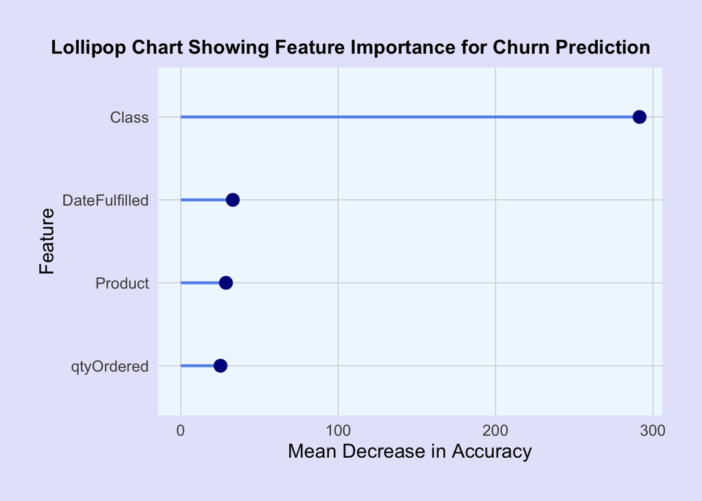

#### Table 4 - Confusion Matrix (Customer Churn Model)

The confusion matrix provides metrics such as accuracy, sensitivity, and specificity, which are key for interpreting model performance in predicting churn.

| Table4: | Confusion Matrix and Statistics |  |
| --- | --- | --- |
|  | Reference |  |
| Prediction | 0 | 1 |
| 0 | 4045 | 135 |
| 1 | 1101 | 1001 |
| Accuracy |  | 0.8032 |
| 95% CI |  | (0.7932, 0.813) |
| No Information Rate |  | 0.8192 |
| P-Value [Acc > NIR] |  | 0.9994 |
| Kappa |  | 0.5012 |
| Mcnemar’s Test P-Value |  | <2e-16 |
| Sensitivity |  | 0.786 |
| Specificity |  | 0.8812 |
| Pos Pred Value |  | 0.9677 |
| Neg Pred Value |  | 0.4762 |
| Prevalence |  | 0.8192 |
| Detection Rate |  | 0.6439 |
| Detection Prevalence |  | 0.6654 |
| Balanced Accuracy |  | 0.8336 |
| ‘Positive’ Class |  | 0 |

##### Customer Churn Model Evaluation

The Model was evaluated using the statistics provided in the confusion matrix. The accuracy on the final model proved to be 80.3% but it was achieved only after several tweaks to the model for example correcting the date format and re-grouping. Originally only a 51% accuracy was seen which meant the model correctly classified about 51% of the cases. However, 80.3% accuracy was eventually achieved to predict churn. The No Information Rate (NIR) was 0.8192, which meant that always predicting majority class (0) would result in 81.92% accuracy. Kappa of 0.5012 indicates moderate agreement between predicted and actual classifications beyond chance, hence did fairly in differenciating classes. Sensitivity (for class 0) of 0.7860 indicated the model correctly identifies 78.6% of the actual 0 cases. This was fairly strong but could still benefit from improvement. Specificity (for class 1) of 0.8812 suggests the model correctly identifies 88.12% of the actual 1 cases, indicating strong performance in identifying class 1 cases. Positive Predictive Value (PPV for class 0) of 0.9677 suggests that when the model predicts 0, it is correct 96.77% of the time. This indicates a high precision for class 0. Negative Predictive Value (NPV for class 1) of 0.4762, suggests that when the model predicts 1, it’s correct only 47.62% of the time. This lower NPV suggests that the model might still be missing some 1 cases. The P-value (<2e-16) for Mcnemar’s Test indicates a statistically significant difference between the error rates for 0 and 1 predictions. This could mean that the model still struggles slightly with misclassification between classes. Over all, the model has a good balance (0.8336) between identifying both classes, though it is better at predicting class 0.

**Inventory Forecast**: A Random Forest Regression model was created to forecast inventory using some of the features from the SSI Sales dataset. The goal of *Inventory Forecast* was to predict quantity that will be ordered for each product in future periods. `qtyOrdered` was the target variable with predictor variables being: `Product, OPCO, Substrate, Month, Year, DayOfWeek, UnitPrice and Class`. Certain Classes were omitted from the data that were irrelevant as well as records with missing substrate. Additional variables were calculated to pass to the model such as day, week and month of the year. The data was partitioned as prior: 80% of the data was used to train the model and 20% was used to test. Feature importance and proximity measure were set within the model for further analysis and the model was evaluated using the root mean square error rate.

```
[1] FALSE
```

```
[1] 0
```

```
[1] "RMSE: 112.20000985852"
```

```
           %IncMSE IncNodePurity
Product   22.32102      69866281
OPCO      18.53756      57212772
Substrate 13.92147       6527239
Month     19.79697      18252323
Year      17.49438      15815264
DayOfWeek 17.45418      10800407
UnitPrice 19.37081      48526382
Class     16.58807      46589684
```

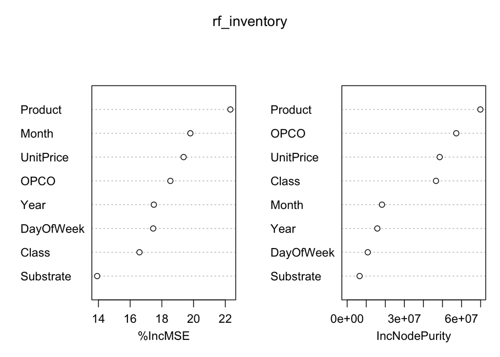

#### Inventory Forecast Model Evaluation

- *Aggregating features*: A grouping by `Product` and `Class` was created to capture patterns specific to each product for each client. This grouping provided more granular values and improved the model’s performance. RMSE calculated dropped to 100.73.
- *K-Fold Cross-Validation*: Further tuning was performed using 5-Fold Cross-Validation to get more robust RMSE estimate. The final value used for the model was mtry = 4 and RMSE calculated was 94.38.
- *XGBoost*: XGBoost package in R proved to capture complex patterns of this data better than the base Random Forest function. XGBoost required data to be in a numeric matrix format and it didn’t handle categorical variables directly. A RMSE of 62.88 was achieved using this gradient boosting method. 62.88 indicates that there is some variability but still reasonable predictive accuracy for larger quantities. However, it still appears to be high since the data has a lot of lower values.

The results are displayed in *Table 5* below for refrence.

#### Table 5 - Model Comparison with RMSE

[output not shown]